# Exploratory Data Analysis (EDA)

Audrey Pentz

September 20, 2018

### **Load the Preprocessed Data**

```r
load("../input_data.RData")
```

### **Remove Stop Words and Tokenize by Sentences, Words and Bigrams**

```r
# sentence tokenization
tidy_sona_sentences <- input_data$sentences

# word tokenization
tidy_sona_words <- input_data$words %>%
  filter(!word %in% stop_words$word, str_detect(word, "[a-z]"))  # remove stop words

# bigram tokenization
bigrams <- tidy_sona_sentences %>%
  unnest_tokens(bigram, sentence, token = "ngrams", n = 2)
# separate the bigrams
bigrams_separated <- bigrams %>%
  separate(bigram, c("word1", "word2"), sep = " ")
# remove stop words
bigrams_filtered <- bigrams_separated %>%
  filter(!word1 %in% stop_words$word) %>%
  filter(!word2 %in% stop_words$word)
# join up the bigrams again
tidy_sona_bigrams <- bigrams_filtered %>%
  unite(bigram, word1, word2, sep = " ")
```

### **Overview of the dataset**

Each president has made a certain number of SONA speeches, depending on their term in office and whether there was 1 speech that year or 2 in the year of an election (pre and post election). Let’s understand the number of sentences and words used by each President and how this varies across each SONA speech.

#### **Average number of Sentences used per President**

```r
# speeches
speech_count <- tidy_sona_words %>%
  group_by(year, president) %>%
  count() %>%
  group_by(president) %>%
  summarise(num_speeches = n())

# avg words per president
avg_sentence_count <- tidy_sona_sentences %>%
  group_by(president) %>%
  summarise(num_sentences = n()) %>%
  left_join(speech_count) %>%
  mutate(avg_sentences = round((num_sentences/num_speeches),0)) %>%
  arrange(desc(avg_sentences))
```

```r
# plot avg words per president
avg_sentence_count %>%
  ungroup(avg_sentences, president) %>%
  mutate(avg_sentences = color_bar("lightblue")(avg_sentences)) %>%
  kable("html", escape = FALSE, align = "l", caption = "Average number of words used per President") %>%
  kable_styling(bootstrap_options =
                  c("striped", "condensed", "bordered"),
                  full_width = FALSE)
```

| president | num_sentences | num_speeches | avg_sentences |
| --- | --- | --- | --- |
| Motlanthe | 346 | 1 | 346 |
| Mandela | 1879 | 6 | 313 |
| Mbeki | 2803 | 9 | 311 |
| Zuma | 2697 | 9 | 300 |
| Ramaphosa | 240 | 1 | 240 |
| deKlerk | 103 | 1 | 103 |

##### **Insights:**

On average, Mandela, Mbeki and Zuma, the 3 longest reigning presidents, used a similar number of sentences per SONA speech at between 300 and 313. De Klerk used the least number of sentences at 103 and Motlanthe the most at 346, nearly 3.5 times as many as De Klerk.

#### **Average Number of Sentences used per SONA**

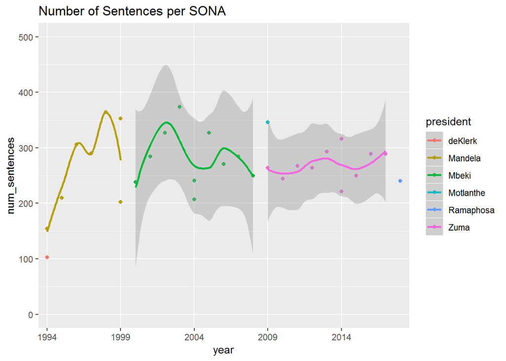

```r
# per SONA
sentence_count <- tidy_sona_sentences %>%
  group_by(president, year, election) %>%
  summarise(num_sentences = n()) %>%
  arrange(desc(num_sentences))

# plot words per SONA
sentence_count %>%
  ggplot(aes(x = as.numeric(year), y = num_sentences, colour = president)) +
  geom_point() +
  geom_smooth(method = "loess", aes(colour = president)) +
  ggtitle("Number of Sentences per SONA") +
  xlab("year") +
  scale_x_discrete(name ="year",
                    limits=c(1994,1999,2004,2009,2014)) +
  scale_y_continuous(limits = c(0,500))
```

##### **Insights:**

On average, Mandela’s number of sentences increases over time more so than Mbeki’s and Zuma’s.

#### **Average number of Words used per President**

We need to create a metric called “avg_words” which is simply the total number of words across all SONA speeches made by a particular president, divided by the total number of SONA speeches that president made.

```r
# speeches
speech_count <- tidy_sona_words %>%
  group_by(year, president) %>%
  count() %>%
  group_by(president) %>%
  summarise(num_speeches = n())

# avg words per president
avg_word_count <- tidy_sona_words %>%
  group_by(president) %>%
  summarise(num_words = n()) %>%
  left_join(speech_count) %>%
  mutate(avg_words = round((num_words/num_speeches),0)) %>%
  arrange(desc(avg_words))
```

```r
# plot avg words per president
avg_word_count %>%
  ungroup(avg_words, president) %>%
  mutate(avg_words = color_bar("lightblue")(avg_words)) %>%
  kable("html", escape = FALSE, align = "l", caption = "Average number of words used per President") %>%
  kable_styling(bootstrap_options =
                  c("striped", "condensed", "bordered"),
                  full_width = FALSE)
```

Average number of words used per President

| president | num_words | num_speeches | avg_words |
| --- | --- | --- | --- |
| Mbeki | 29952 | 9 | 3328 |
| Motlanthe | 3206 | 1 | 3206 |
| Mandela | 16801 | 6 | 2800 |
| Zuma | 23554 | 9 | 2617 |
| Ramaphosa | 2258 | 1 | 2258 |
| deKlerk | 783 | 1 | 783 |

##### **Insights:**

On average, Mbeki used the most words in his SONA speeches, followed by Motlanthe and de Klerk used the least. Mandela and Zuma are ranked in the middle of their peers. The current president (Ramaphosa) used fewer words than all of his post 1994 peers.

#### **Number of Words used per SONA speech**

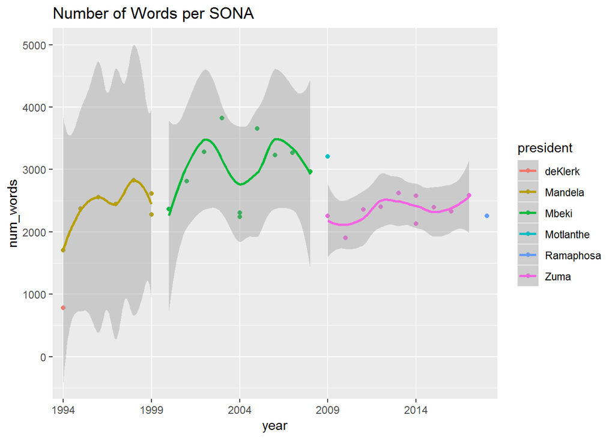

```r
# per SONA
word_count <- tidy_sona_words %>%
  group_by(president, year, election) %>%
  summarise(num_words = n()) %>%
  arrange(desc(num_words))

# plot words per SONA
word_count %>%
  ggplot(aes(x = as.numeric(year), y = num_words, colour = president)) +
  geom_point() +
  geom_smooth(method = "loess", aes(colour = president)) +
  ggtitle("Number of Words per SONA") +
  xlab("year") +
  scale_x_discrete(name ="year",
                    limits=c(1994,1999,2004,2009,2014))
```

##### **Insights:**

Of the 3 presidents that have made more than 1 SONA speech, Mbeki used more words on average than both Mandela and Zuma and the variance in the number of words used per SONA speech is also higher for Mbeki. In 2004, which was an election year, the average number of words Mbeki used was lower in both his pre- and post-election speeches. Towards the end of his term, his average number of words also dropped off. The data suggests that perhaps Mbeki’s average number of words is correlated with his confidence in being re-elected President.

### **What are the common words used across all SONA speeches?**

```r
# word cloud for words
word_count <- tidy_sona_words %>%
  filter(!(word %in% c("government", "south", "africa", "african"))) %>%    # remove obvious words dominating word cloud
  count(word, sort = TRUE)

wordcloud2(word_count[1:300, ], size = .4, color='random-dark')
```

[interactive chart not shown]

##### **Insights:**

If we remove the dominant words: “government”, “south”, “africa” and “african”, the most common words across all SONA speeches shown in the WordCloud are “people”, “development”, “national”, “country”, “public”, “ensure”, “continue”, “regard” and “economic”. One can hover over the html version to get the counts.

### **What are the common bigrams used across all SONA speeches?**

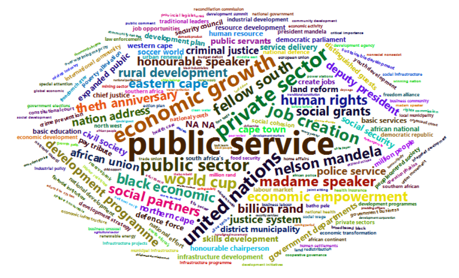

```r
# word cloud for bigrams
bigram_count <- tidy_sona_bigrams %>%
  filter(!(bigram %in% c("south africa", "south africans", "south african", "local government"))) %>%    # remove obvious words dominating word cloud
  count(bigram, sort = TRUE)

# wordcloud2(bigram_count[1:200, ], size = .3, color='random-dark')

knitr::include_graphics("C:/Users/nb174984/Desktop/Masters Data Science/Data Science for Industry/dsi-assign2/WordCloud.png")
```

##### **Insights:**

If we remove the dominant bigrams: “south africa”, “south africans”, “south african” and “local government”, the most common bigrams across all SONA speeches shown in the WordCloud are “public service”, “economic growth”, “private sector”, “united nations”, “public sector”, “job creation”, “world cup”, “nelson mandela”, “economic empowerment”, “black economic”, “human rights”, “development programme”, “rural development” and “social grants”.

### **Lexical Diversity per President**

Lexical diversity refers to the number of unique words used in each SONA.

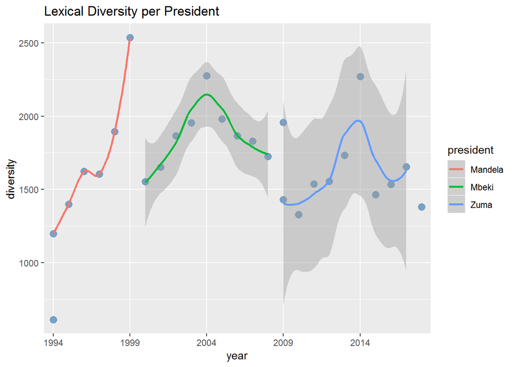

```r
# word tokenization
diversity_per_year <- input_data$words %>%   # don't remove stop words this time
  group_by(president, year) %>%
  summarise(diversity = n_distinct(word)) %>%
  arrange(desc(diversity))

diversity_per_year %>%
  ggplot(aes(x = as.numeric(year), y = diversity, colour = president)) +
  geom_point(color = "steelblue",
               alpha = .7,                 # transparency
               size = 3) +                 # point size
  geom_smooth(method = "loess", aes(colour = president)) +
  ggtitle("Lexical Diversity per President") +
  scale_x_discrete(name ="year",
                    limits=c(1994,1999,2004,2009,2014))
```

##### **Insights:**

It’s interesting that whilst the trend in the number of unique words used was most often upwards with Mandela, Mbeki and Zuma both show a mostly upward trend in the lead up to the election year, followed by a mostly downward trend after reaching the 2250 unique words mark in their post election speech.

### **Lexical Density per President**

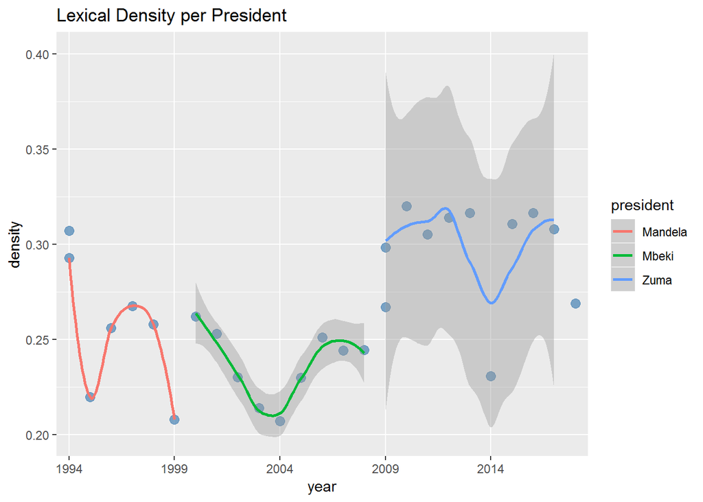

```r
# word tokenization
density_per_year <- input_data$words %>%   # don't remove stop words this time
  group_by(president, year) %>%
  summarise(density = n_distinct(word) / n()) %>%
  arrange(desc(density))

density_per_year %>%
  ggplot(aes(x = as.numeric(year), y = density, colour = president)) +
  geom_point(color = "steelblue",
               alpha = .7,                 # transparency
               size = 3) +                 # point size
  geom_smooth(method = "loess", aes(colour = president)) +
  ggtitle("Lexical Density per President") +
  scale_x_discrete(name ="year",
                    limits=c(1994,1999,2004,2009,2014))
```